# Final Project

YU FAN

2020/4/22

```r
knitr::opts_chunk$set(echo = FALSE,
                      comment = NA, # Recommended
                      fig.path = "./figures/",  # Store all figures here in relative path (make the folder first)
                      fig.align = "center",
                      fig.width = 7,
                      fig.height = 7,
                      message = FALSE, # Turn off load messages
                      warning = FALSE # Turn off warnings
                      )
```

## Introduction

In this project, we try to analysis the evolution of COVID-19 in the whole world. We use two dataset in our project, the first one is breakdown of cases and deaths of COVID-19 by country in the https://www.worldometers.info/coronavirus/. And the second data is come from https://worldpopulationreview.com/countries/ which contains the world population data of each country.

In the following part, we first try to visuliza the death rate(total death/population) Prevalence rate (total COVID-19 case/population)and of each country in the world by the leaflet map. Then we try to analyze the realtionship of total death with the other factors. The factors contain total case number, total recover number,SeriousCritical number, active case number, total test number, total population and population density. The method we used is correlation coefficient analysis and linear regression.

## Crawling data and Convert to data frame

## do some data cleaning

| Country | TotalCases | NewCases | TotalDeaths | NewDeaths | TotalRecovered | ActiveCases | SeriousCritical | Tot Cases/1M pop | Deaths/1M pop | TotalTests | Tests/1M pop | Continent | Rank | 2020 Population | Growth Rate | Area (km²) | 2018 Density | Prevalence | Mortality |
| --- | --- | --- | --- | --- | --- | --- | --- | --- | --- | --- | --- | --- | --- | --- | --- | --- | --- | --- | --- |
| United States | 1212835 |  | 69921 | NA | 188027 | 954887 | 16050 | 3,664 | 211 | 7462431 | 22,545 | North America | 3 | 331002651 | 0.59% | 9372610.00 | 35/km² | 0.0036641 | 0.0002112 |
| Spain | 248301 |  | 25428 | NA | 151633 | 71240 | 2254 | 5,311 | 544 | 1932455 | 41,332 | Europe | 30 | 46754778 | 0.04% | 505992.00 | 92/km² | 0.0053107 | 0.0005439 |
| Italy | 211938 |  | 29079 | NA | 82879 | 99980 | 1479 | 3,505 | 481 | 2191403 | 36,244 | Europe | 23 | 60461826 | -0.15% | 301336.00 | 201/km² | 0.0035053 | 0.0004809 |
| UK | 190584 |  | 28734 | NA | NA | 161506 | 1559 | 2,807 | 423 | 1291591 | 19,026 | Europe | 21 | 67886011 | 0.53% | 242900.00 | 278/km² | 0.0028074 | 0.0004233 |
| France | 169462 |  | 25201 | NA | 51371 | 92890 | 3696 | 2,596 | 386 | 1100228 | 16,856 | Europe | 22 | 65273511 | 0.22% | 551695.00 | 118/km² | 0.0025962 | 0.0003861 |
| Germany | 166152 |  | 6993 | NA | 132700 | 26459 | 1949 | 1,983 | 83 | 2547052 | 30,400 | Europe | 19 | 83783942 | 0.32% | 357114.00 | 234/km² | 0.0019831 | 0.0000835 |
| Russia | 145268 |  | 1356 | NA | 18095 | 125817 | 2300 | 995 | 9 | 4300000 | 29,465 | Europe | 9 | 145934462 | 0.04% | 17098242.00 | 9/km² | 0.0009954 | 0.0000093 |
| Turkey | 127659 |  | 3461 | NA | 68166 | 56032 | 1384 | 1,514 | 41 | 1171138 | 13,886 | Asia | 17 | 84339067 | 1.09% | 783562.00 | 106/km² | 0.0015136 | 0.0000410 |
| Brazil | 108266 |  | 7343 | NA | 45815 | 55108 | 8318 | 509 | 35 | 339552 | 1,597 | South America | 6 | 212559417 | 0.72% | 8515767.00 | 25/km² | 0.0005093 | 0.0000345 |
| Iran | 98647 |  | 6277 | NA | 79379 | 12991 | 2676 | 1,174 | 75 | 508288 | 6,052 | Asia | 18 | 83992949 | 1.30% | 1648195.00 | 50/km² | 0.0011745 | 0.0000747 |
| Canada | 60772 |  | 3854 | NA | 26017 | 30901 | 557 | 1,610 | 102 | 919368 | 24,359 | North America | 39 | 37742154 | 0.89% | 9984670.00 | 4/km² | 0.0016102 | 0.0001021 |
| Belgium | 50267 |  | 7924 | NA | 12378 | 29965 | 655 | 4,337 | 684 | 440700 | 38,025 | Europe | 81 | 11589623 | 0.44% | 30528.00 | 378/km² | 0.0043372 | 0.0006837 |
| Peru | 47372 |  | 1344 | NA | 14427 | 31601 | 694 | 1,437 | 41 | 385492 | 11,692 | South America | 43 | 32971854 | 1.42% | 1285216.00 | 25/km² | 0.0014367 | 0.0000408 |
| India | 46437 |  | 1566 | NA | 12847 | 32024 | NA | 34 | 1 | 1107233 | 802 | Asia | 2 | 1380004385 | 0.99% | 3287590.00 | 416/km² | 0.0000336 | 0.0000011 |
| Netherlands | 40770 |  | 5082 | NA | NA | 35438 | 683 | 2,379 | 297 | 235909 | 13,768 | Europe | 69 | 17134872 | 0.22% | 41850.00 | 409/km² | 0.0023794 | 0.0002966 |
| Ecuador | 31881 |  | 1569 | NA | 3433 | 26879 | 159 | 1,807 | 89 | 80171 | 4,544 | South America | 67 | 17643054 | 1.55% | 276841.00 | 63/km² | 0.0018070 | 0.0000889 |
| Switzerland | 29981 |  | 1784 | NA | 25200 | 2997 | 141 | 3,464 | 206 | 282750 | 32,670 | Europe | 101 | 8654622 | 0.74% | 41284.00 | 208/km² | 0.0034642 | 0.0002061 |
| Saudi Arabia | 28656 |  | 191 | NA | 4476 | 23989 | 143 | 823 | 5 | 365093 | 10,487 | Asia | 41 | 34813871 | 1.59% | 2149690.00 | 16/km² | 0.0008231 | 0.0000055 |
| Portugal | 25524 |  | 1063 | NA | 1712 | 22749 | 143 | 2,503 | 104 | 450000 | 44,132 | Europe | 89 | 10196709 | -0.29% | 92090.00 | 111/km² | 0.0025032 | 0.0001042 |
| Mexico | 24905 | +1,434 | 2271 | 117 | 13447 | 9187 | 378 | 193 | 18 | 100041 | 776 | North America | 10 | 128932753 | 1.06% | 1964375.00 | 65/km² | 0.0001932 | 0.0000176 |
| Sweden | 22721 |  | 2769 | NA | 4074 | 15878 | 455 | 2,250 | 274 | 119500 | 11,833 | Europe | 91 | 10099265 | 0.63% | 450295.00 | 22/km² | 0.0022498 | 0.0002742 |
| Ireland | 21772 |  | 1319 | NA | 13386 | 7067 | 93 | 4,409 | 267 | 169377 | 34,302 | Europe | 124 | 4937786 | 1.13% | 70273.00 | 69/km² | 0.0044093 | 0.0002671 |
| Pakistan | 20941 |  | 476 | NA | 5635 | 14830 | 111 | 95 | 2 | 212511 | 962 | Asia | 5 | 220892340 | 2.00% | 881912.00 | 246/km² | 0.0000948 | 0.0000022 |
| Chile | 20643 |  | 270 | NA | 10415 | 9958 | 464 | 1,080 | 14 | 214131 | 11,202 | South America | 63 | 19116201 | 0.87% | 756102.00 | 25/km² | 0.0010799 | 0.0000141 |
| Singapore | 18778 |  | 18 | NA | 1457 | 17303 | 22 | 3,210 | 3 | 143919 | 24,600 | Asia | 114 | 5850342 | 0.79% | 710.00 | 8,175/km² | 0.0032097 | 0.0000031 |
| Belarus | 17489 |  | 103 | NA | 3259 | 14127 | 92 | 1,851 | 11 | 211369 | 22,369 | Europe | 96 | 9449323 | -0.03% | 207600.00 | 46/km² | 0.0018508 | 0.0000109 |
| Israel | 16246 |  | 235 | NA | 10064 | 5947 | 70 | 1,877 | 27 | 404285 | 46,708 | Asia | 100 | 8655535 | 1.60% | 20770.00 | 410/km² | 0.0018769 | 0.0000272 |
| Qatar | 16191 |  | 12 | NA | 1810 | 14369 | 72 | 5,620 | 4 | 106795 | 37,068 | Asia | 139 | 2881053 | 1.73% | 11586.00 | 244/km² | 0.0056198 | 0.0000042 |
| Austria | 15621 |  | 600 | NA | 13316 | 1705 | 111 | 1,734 | 67 | 279071 | 30,986 | Europe | 97 | 9006398 | 0.57% | 83871.00 | 107/km² | 0.0017344 | 0.0000666 |
| Japan | 15078 |  | 536 | NA | 4156 | 10386 | 328 | 119 | 4 | 184586 | 1,459 | Asia | 11 | 126476461 | -0.30% | 377930.00 | 336/km² | 0.0001192 | 0.0000042 |

[output cut: 176 more lines]

## mortality and morbidity of COVID-19 visulization

```
[1] 206
```

```
[1] 199
```

[interactive chart not shown]

## analyze the relationship of total death with the other factors

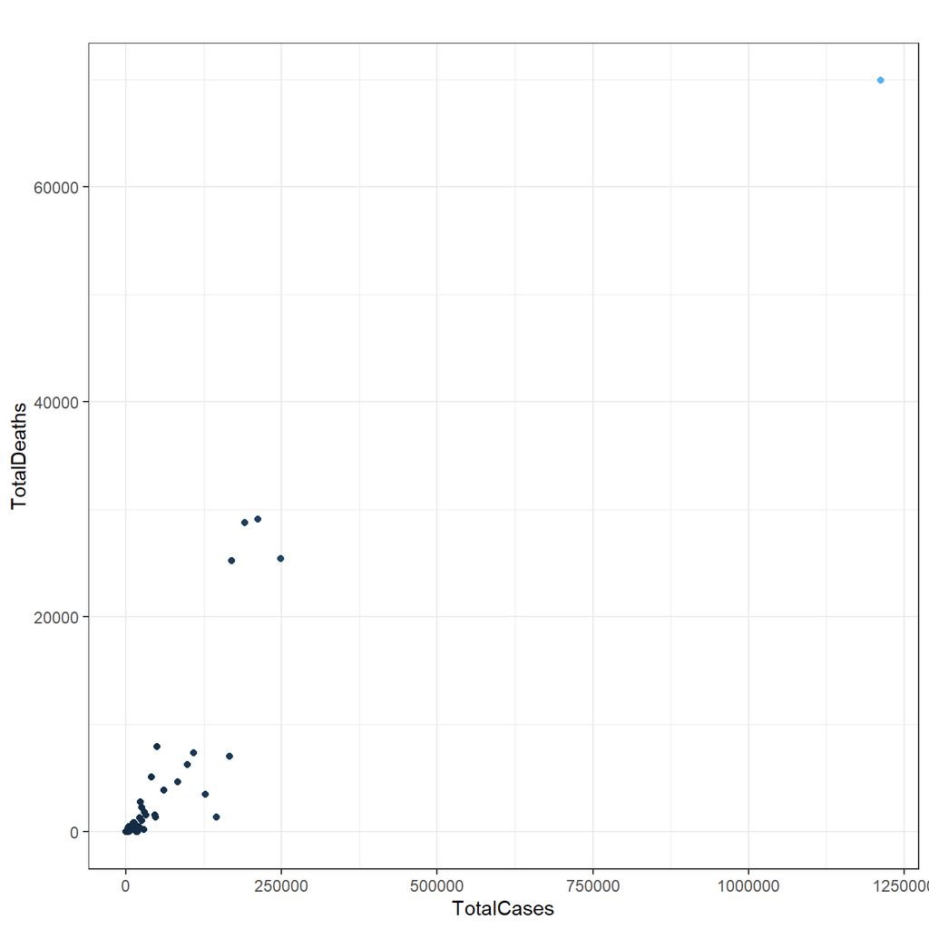

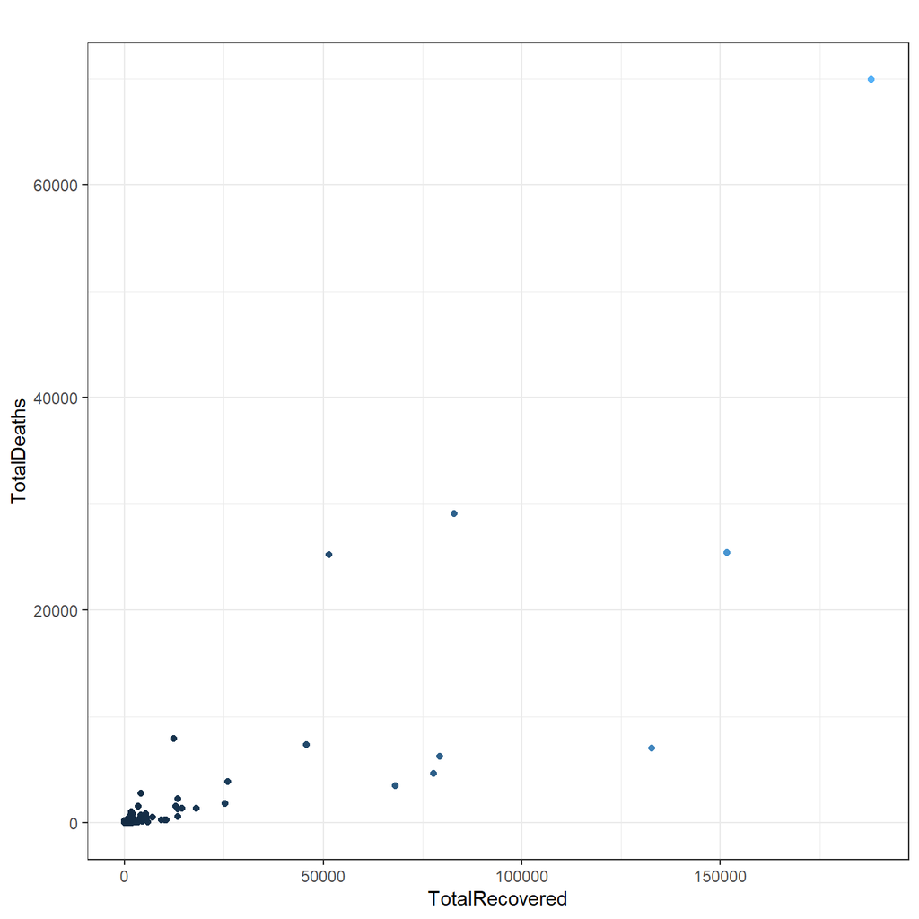

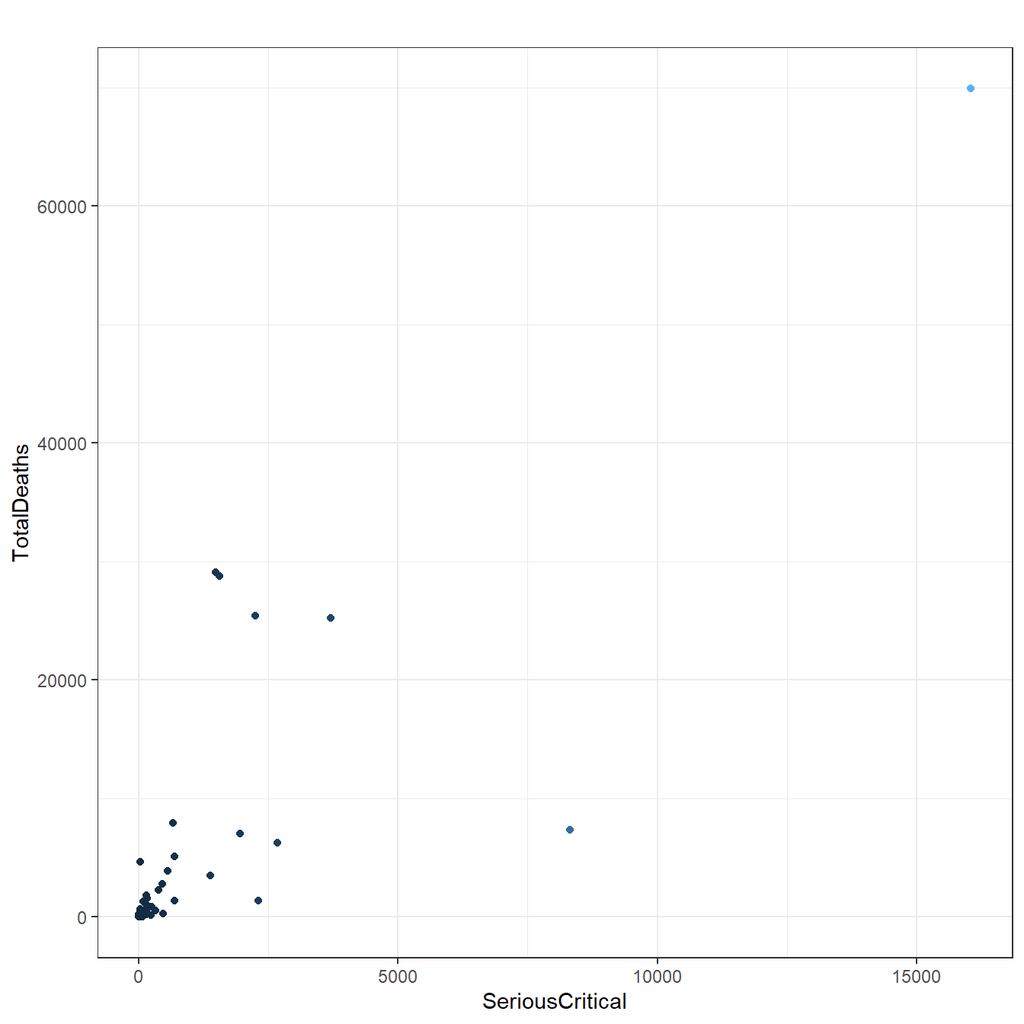

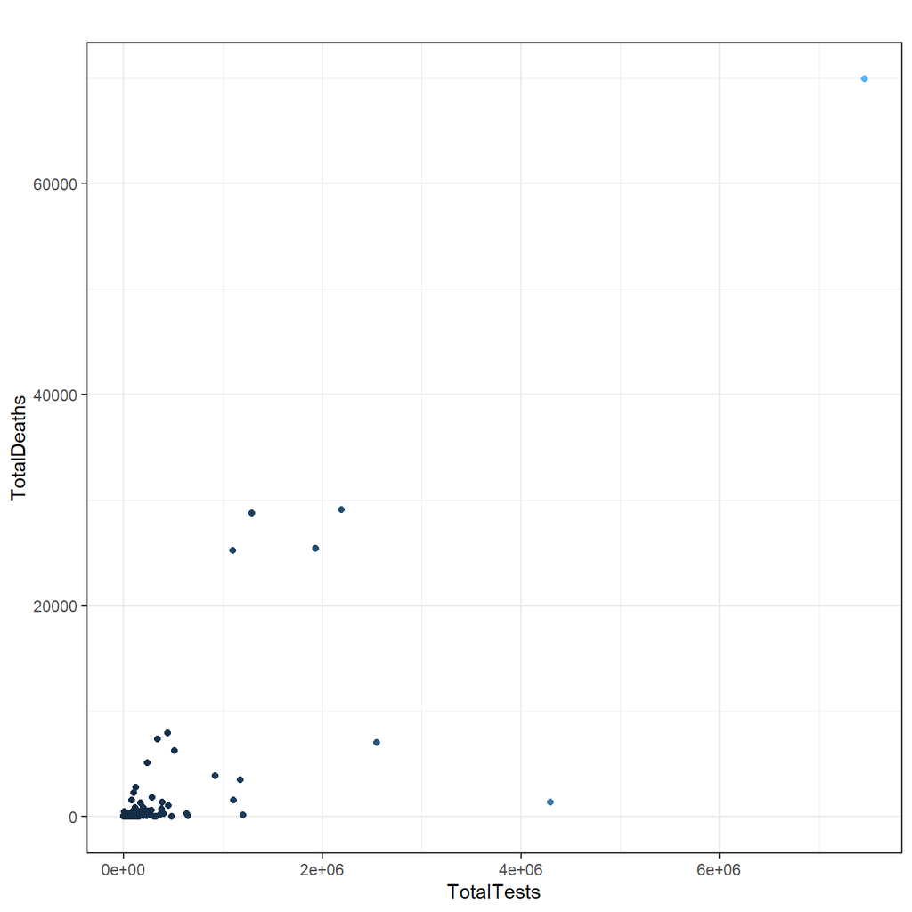

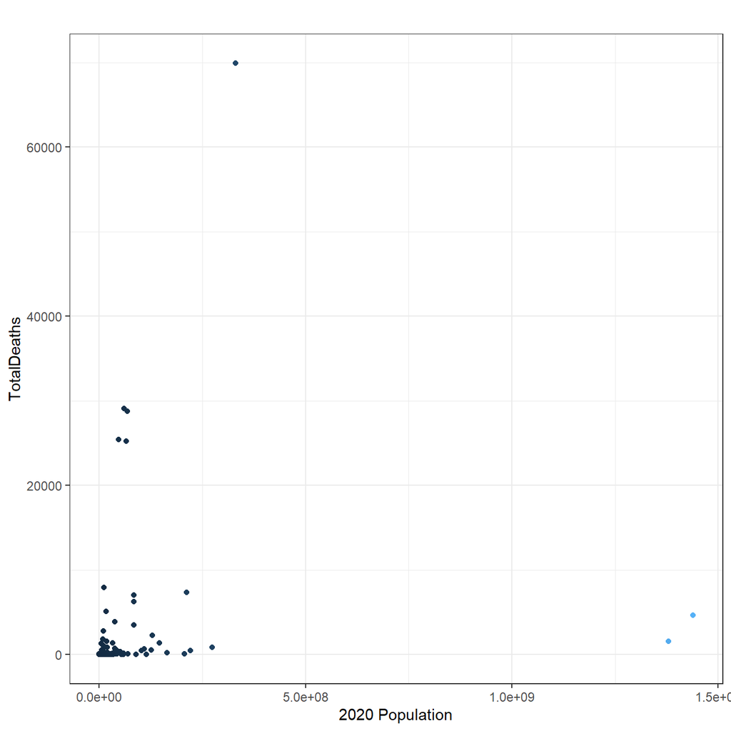

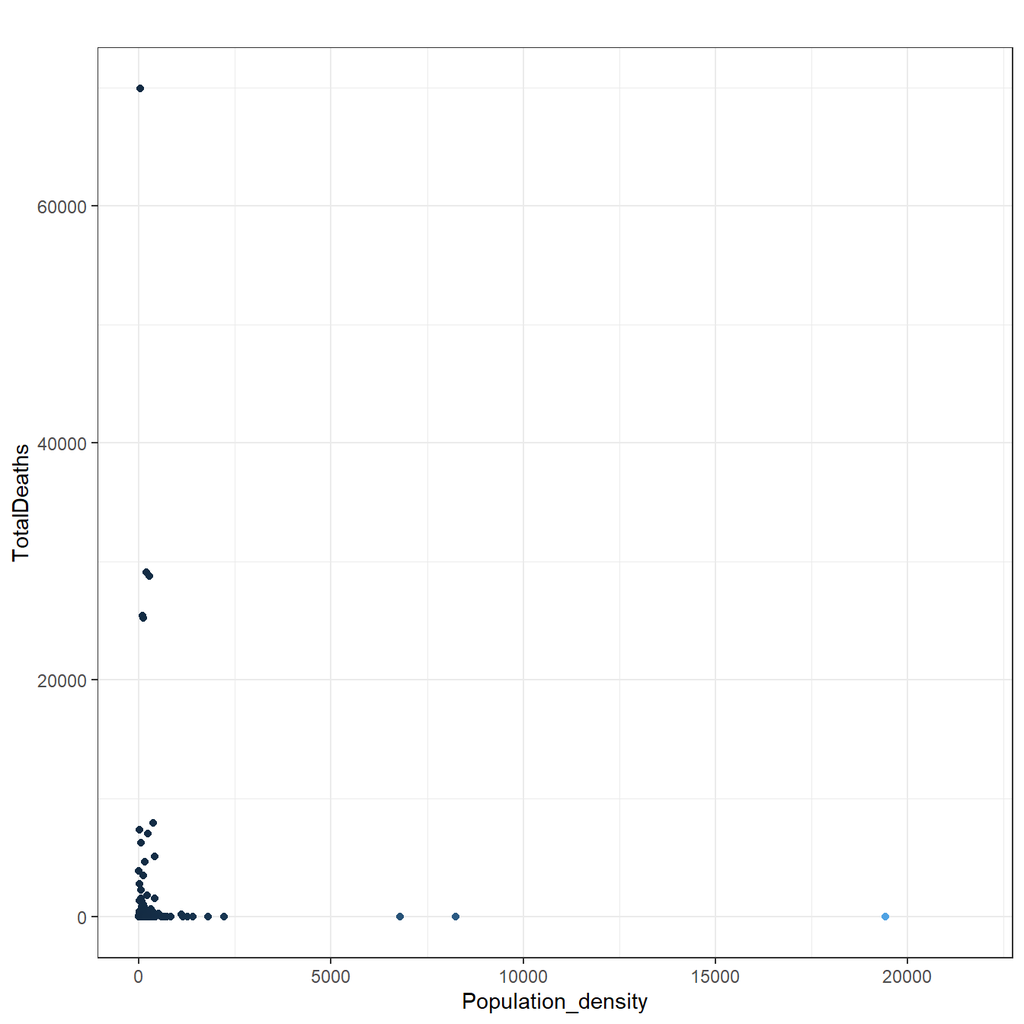

```
[1] 0.9325181
```

```
[1] 0.830042
```

```
[1] 0.8397257
```

```
[1] 0.8895384
```

```
[1] 0.8163041
```

```
[1] 0.1782067
```

```
[1] -0.03323684
```

## fit a linear model to learn the relationship of total death with the other factors

```
Call:
lm(formula = TotalDeaths ~ TotalCases + TotalRecovered + SeriousCritical +
    ActiveCases + TotalTests + `2020 Population` + Population_density,
    data = dataworld)

Residuals:
       Min         1Q     Median         3Q        Max
-1.297e-10 -5.932e-12  8.070e-13  6.600e-12  2.409e-10

Coefficients:
                     Estimate Std. Error    t value Pr(>|t|)
(Intercept)        -5.971e-11  3.761e-12 -1.587e+01   <2e-16 ***
TotalCases          1.000e+00  1.259e-15  7.940e+14   <2e-16 ***
TotalRecovered     -1.000e+00  1.445e-15 -6.922e+14   <2e-16 ***
SeriousCritical    -9.850e-15  4.786e-15 -2.058e+00    0.042 *
ActiveCases        -1.000e+00  1.342e-15 -7.453e+14   <2e-16 ***
TotalTests          4.156e-18  8.760e-18  4.740e-01    0.636
`2020 Population`  -2.616e-20  8.141e-20 -3.210e-01    0.749
Population_density  1.191e-15  2.929e-15  4.070e-01    0.685
---
Signif. codes:  0 '***' 0.001 '**' 0.01 '*' 0.05 '.' 0.1 ' ' 1

Residual standard error: 3.19e-11 on 107 degrees of freedom
  (91 observations deleted due to missingness)
Multiple R-squared:      1, Adjusted R-squared:      1
F-statistic: 9.676e+29 on 7 and 107 DF,  p-value: < 2.2e-16
```